# Лабораторная работа № 4

Агентная SIR: города, миграция и оптимизация

Куокконен Дарина Андреевна

Российский университет дружбы народов имени Патриса Лумумбы

НФИбд-01-23

2026-08-31

## Агентная модель связывает три города

Цель — исследовать заражения, перемещения и выявление инфекции на уровне отдельных людей.

- выполнить пять основных сценариев;
- сравнить четыре параметрических расширения;
- решить шесть дополнительных заданий;
- оптимизировать пик и смертность методом BorgMOEA;
- проверить ограничение пика на новых seed;
- включить все 12 сценариев в выполненные блокноты.

## Один шаг включает миграцию и передачу инфекции

$$S\to I\to R,\qquad R\to I$$

Poisson(β) — цель успешных заражений.

Миграция → передача → срок болезни → исход.

Агенты посещают города, заражают доступных соседей и стареют по болезни.  
Poisson задаёт цель успешных заражений, а не фиксированное число попыток.

**3000** — людей в начале

**14 дней** — период инфекции

## Миграция соединяет локальные эпидемии

$$M_{ij}\propto(N_i+N_j)/N_i$$

$$\sum_jM_{ij}=1$$

$$M_{ii}=1-m,\quad M_{ij}=m/(C-1)$$

Три равных города: в базовой матрице все вероятности равны 1/3.  
Сканирование m меняет вероятность покинуть город.  
Горизонт серии — 150 дней.

**3** — города

**0…0,5** — интенсивность m

## Двенадцать сценариев разделяют вычисления

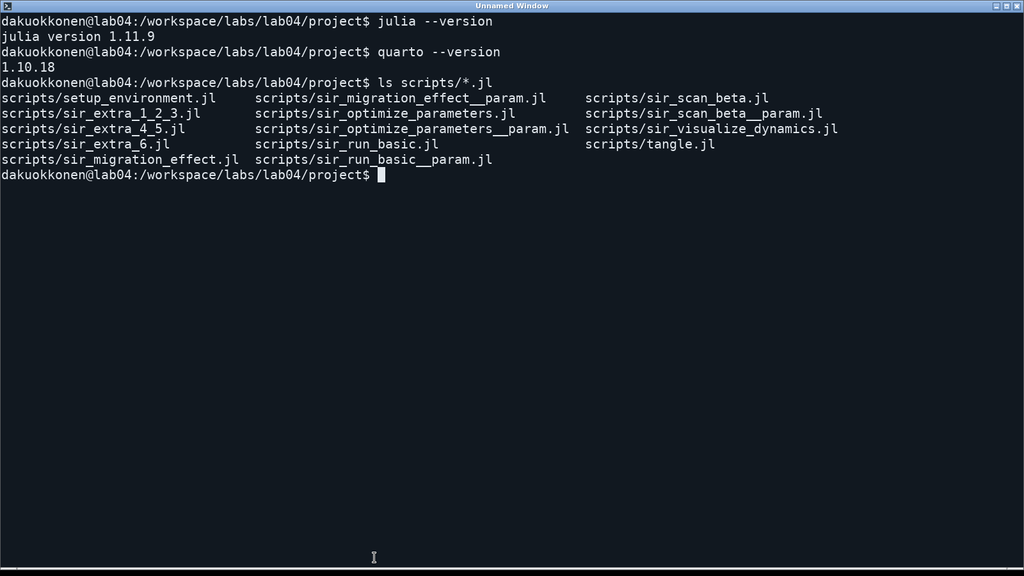

Julia 1.11.9  
Agents.jl и Graphs.jl  
BlackBoxOptim.jl  
Plots.jl  
CSV и JLD2  
Literate.jl и IJulia  
Версии в Manifest.toml.

## Модель отделена от опытов и анализа CSV

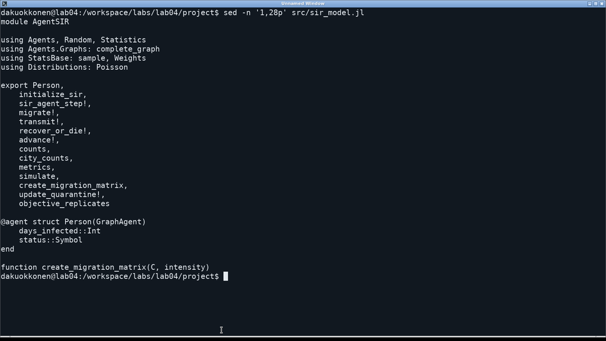

src/sir_model.jl

- состояния агента
- миграция
- заражение
- выздоровление
- карантин
- целевые функции  
  src/experiments.jl  
  сохраняет результаты.

## Базовый пик охватывает всю живую популяцию

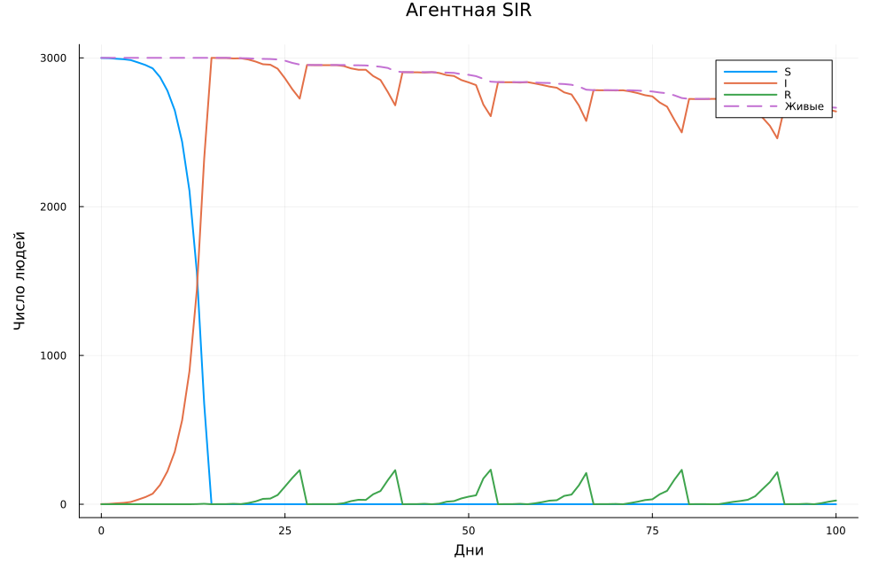

**100%** — максимум I / живые

**15** — день пика

**335** — умерших к дню 100

Повторное заражение и каскады внутри дня.

## При росте β эпидемия достигает всех городов

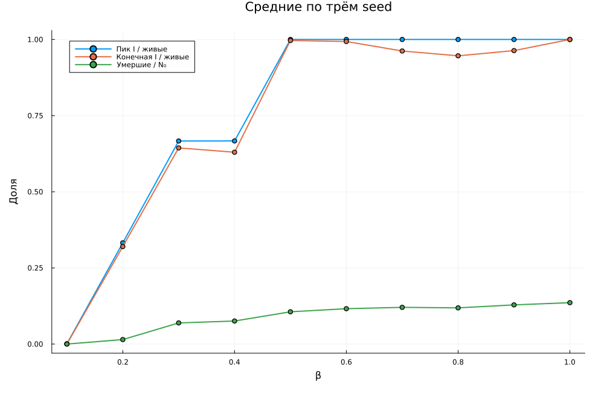

| β | Средний пик |
| --- | --- |
| 0,1 | 0,0009 |
| 0,2 | 0,3322 |
| 0,3 | 0,6667 |
| 0,4 | 0,6669 |
| 0,5 | 1,0000 |

По три seed на точку. Ступени отражают распространение между городами.

## Время пика не убывает монотонно с миграцией

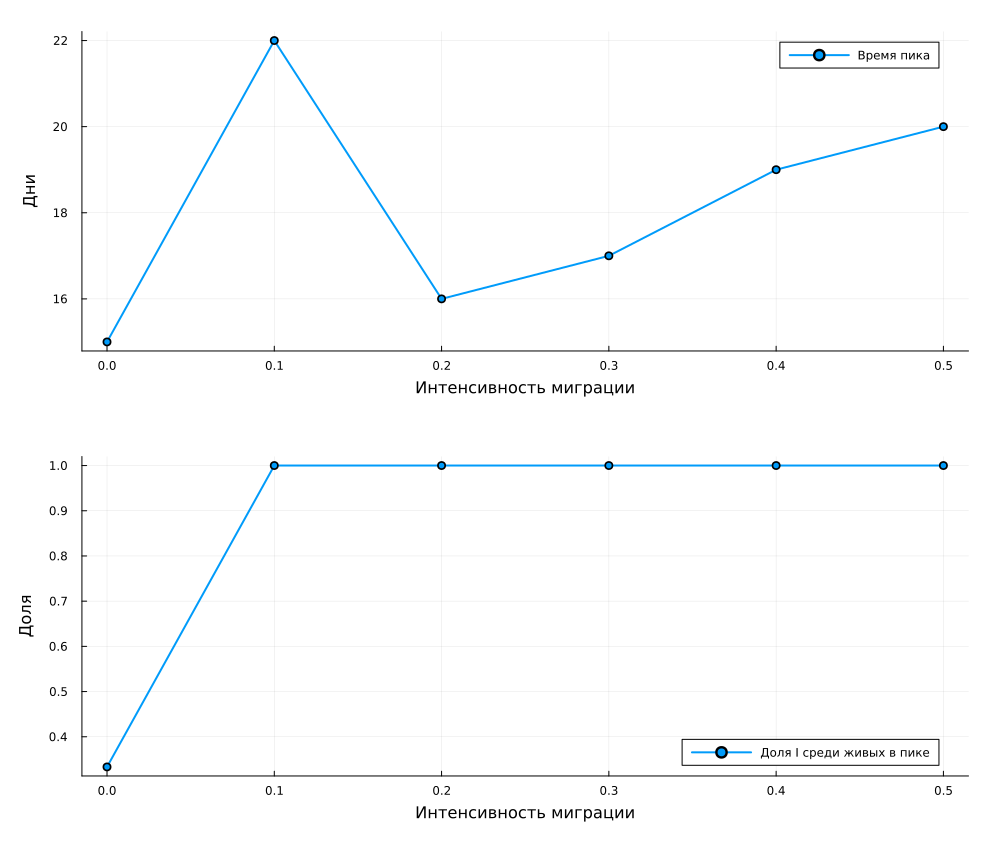

m = 0: 15 дней  
m = 0,1: 22 дня  
m = 0,2: 16 дней  
m = 0,5: 20 дней

Без миграции эпидемия локальна. Среди ненулевых m быстрее всего вариант 0,2.

## Период болезни и выявление исследованы отдельно

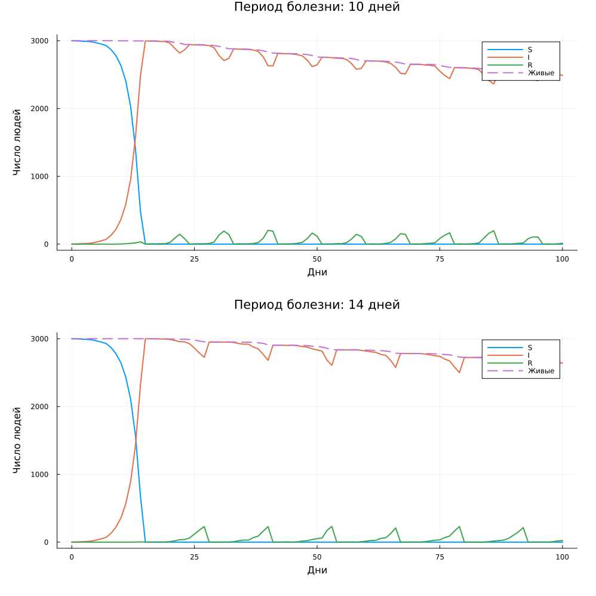

Период инфекции: 10 и 14 дней

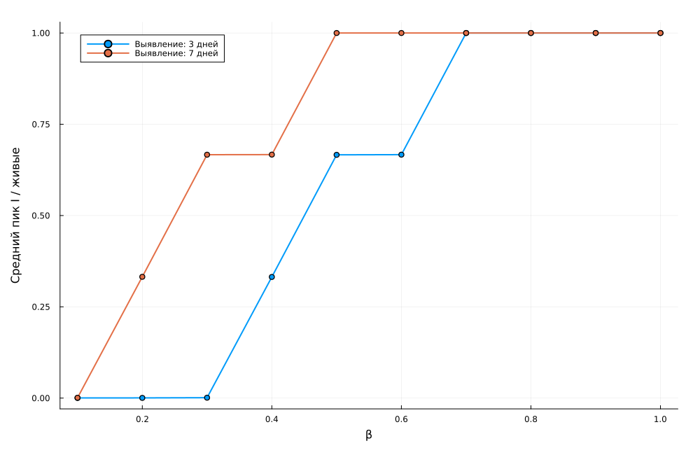

Выявление: на 3-й и 7-й день

## Размеры городов меняют результат миграции

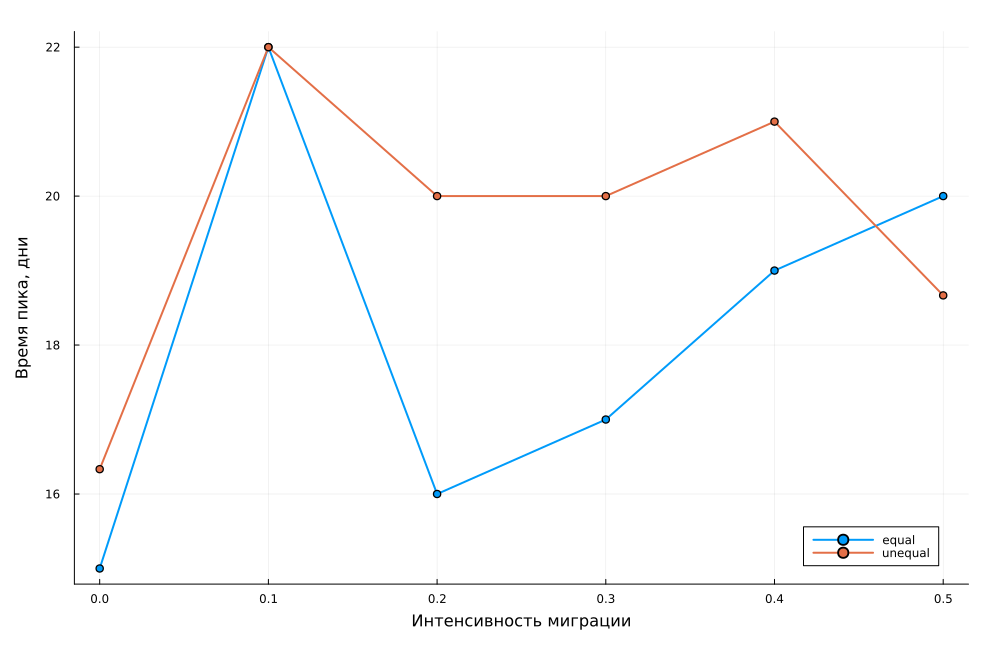

Два набора населения:  
1000 / 1000 / 1000  
500 / 1000 / 1500  
6 интенсивностей  
3 seed на точку  
Всего 36 прогонов.

## BorgMOEA одновременно снижает две цели

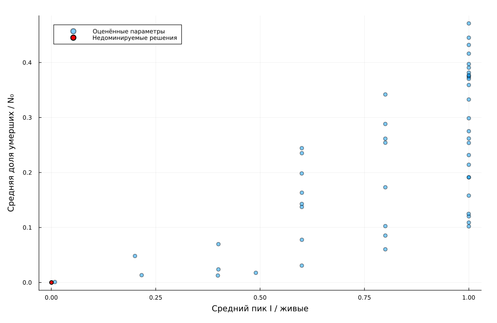

Пик и смертность: seed 43–47

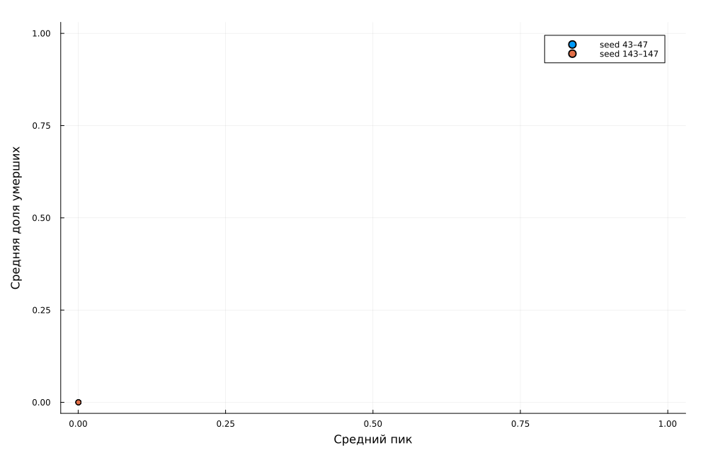

Повторный поиск: seed 143–147

## Отдельный сценарий анализирует готовые CSV

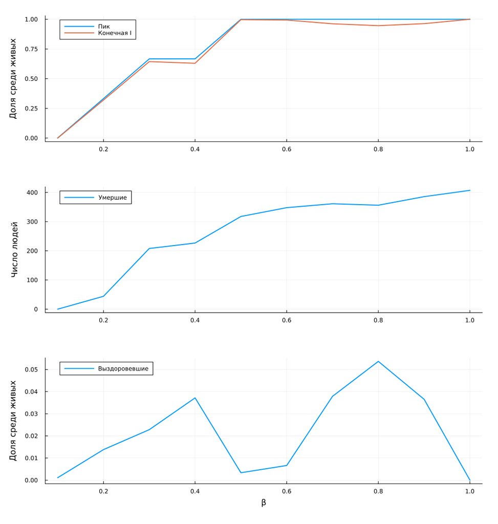

sir_visualize_dynamics

- пик и конечная I
- число умерших
- доля выздоровевших  
  CSV сканирования β читается с диска.  
  Новой симуляции нет.

## Порог агентной модели отличается от ОДУ

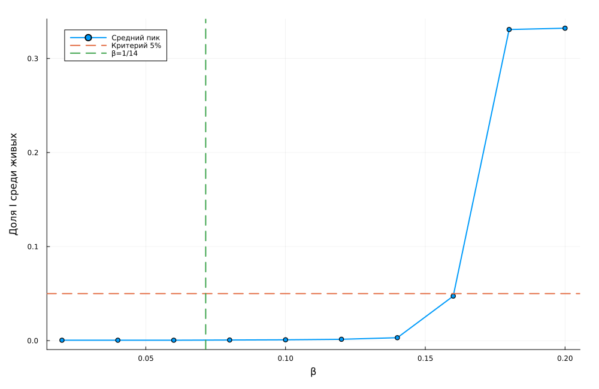

Ориентир R₀ = 7  
ОДУ: 1/14 ≈ 0,0714  
Сетка: β = 0,18  
Критерий: пик > 5%

Это первый порог сетки по среднему пику, а не точная аналитическая граница.

## Неоднородные города связаны перемещениями

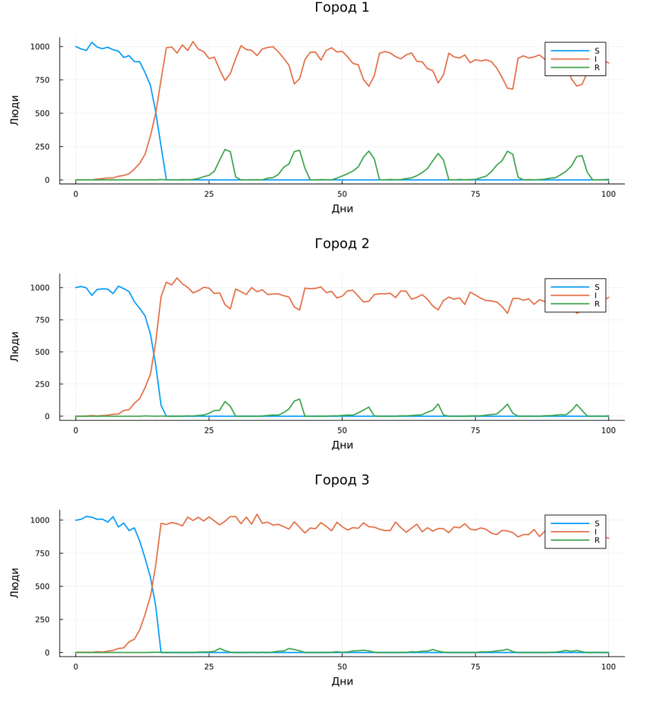

β городов: 0,2 / 0,5 / 0,8

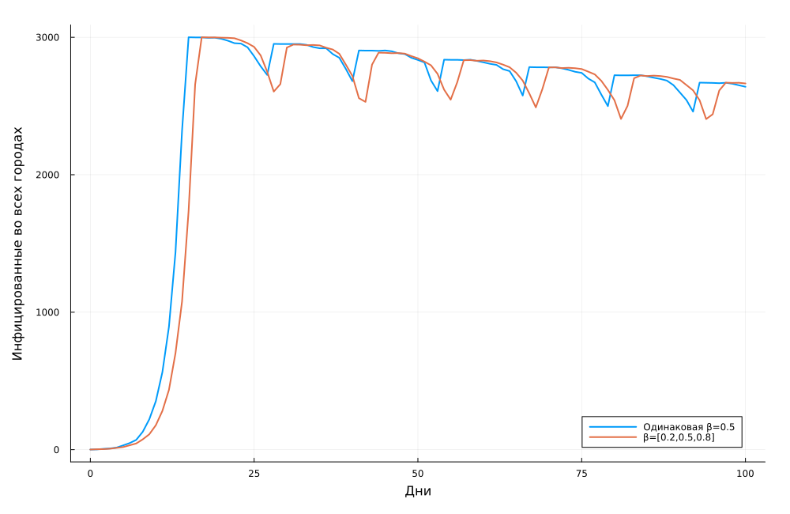

Число заражённых: одинаковые и разные β

## Заданный карантин не уменьшил высоту пика

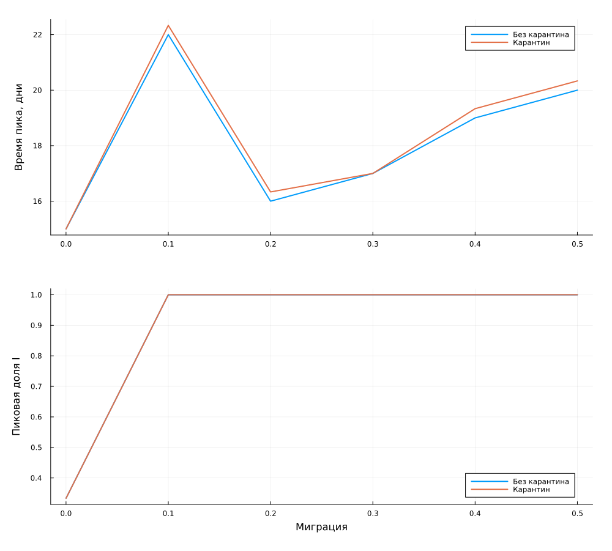

Порог закрытия: 10%  
Закрыт только выезд  
Снижение пика: 0  
Задержка: 0…0,33 дня

К моменту закрытия инфекция может уже находиться в других городах.

## Ограниченный поиск проверен на 20 новых seed

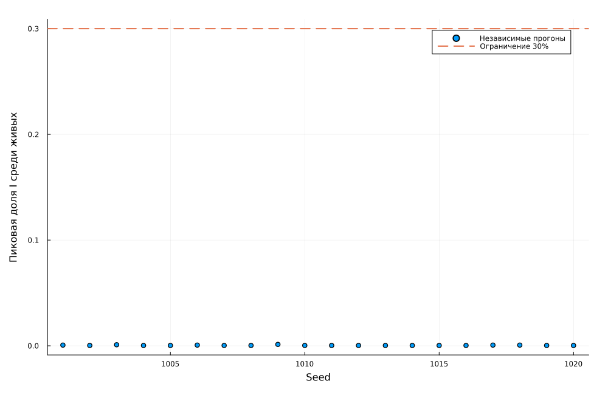

**0,133%** — наибольший пик проверки

**20 из 20** — пик ниже 30%

**0** — умерших в проверке

β = 0,1; выявление: 3 дн.; вероятность смерти 0,01.

## Конечная проверка не даёт гарантии для всех траекторий

Выводы относятся к учебной агентной модели и конечному набору случайных прогонов, а не к реальной инфекции.

- оптимизация использует пять обучающих seed;
- проверка использует независимые seed 1001–1020;
- раннее затухание даёт мало событий заражения;
- решения возле границ диапазонов не уникальны;
- конечный поиск не доказывает глобальный оптимум;
- эпидемиологическая калибровка не выполнялась.

## 103 теста проверяют учёт и правила агентов

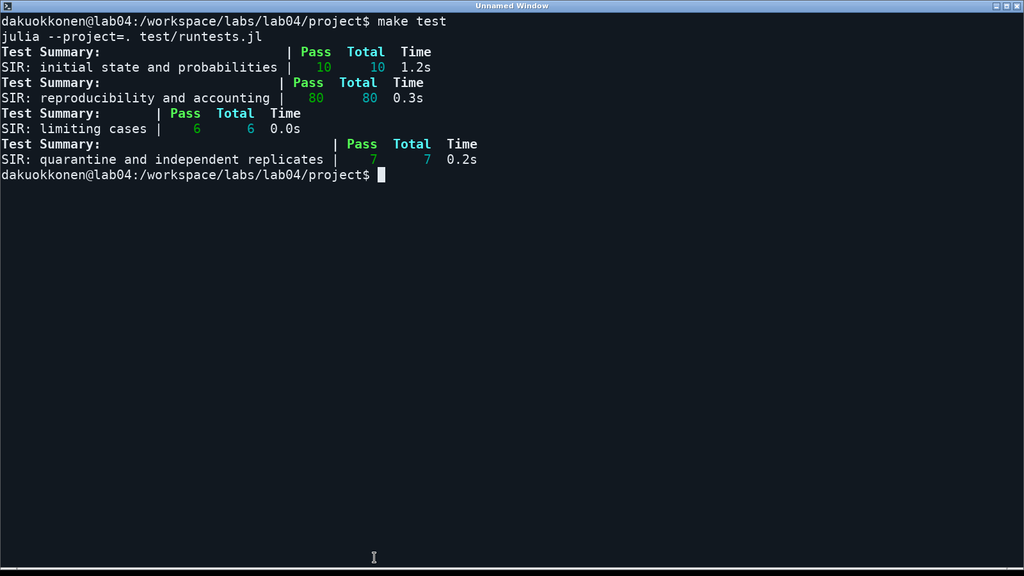

10 — инициализация  
80 — учёт и seed  
6 — предельные случаи  
7 — карантин и повторы  
✓ живые + умершие = N₀  
✓ вероятности миграции  
✓ независимые оценки  
✓ нулевая передача

## Все сценарии имеют производные форматы

```bash
make tangle
make run
make notebooks
make docs
make test
```

12 литературных исходников

- чистый Julia-код;
- 12 выполненных IPYNB;
- QMD и HTML-документация;
- 14 научных рисунков;
- CSV, JLD2 и оценки поиска;
- отчёт DOCX и PDF;
- презентация HTML и PPTX.

## Миграция и выявление меняют ход эпидемии

- Реализованы все основные и дополнительные задания главы 4.
- Последовательное обновление допускает быстрые каскады.
- Заданный карантин не уменьшил пик в выполненной серии.
- Ограничение 30% выполнено во всех 20 проверочных прогонах.
- Результаты не являются прогнозом реальной эпидемии.